# Sampling-oriented modelling of cancer evolution

Author

Paweł Kuś

# Introduction

The rapid development of Next Generation Sequencing (NGS) methods resulted in the development of many methods for the deconvolution of tumor subclonal structure from the NGS data. Whereas many of them figure out tumor subclonal structure by clustering the mutations with similar allelic frequencies, recently published MOBSTER applies the population genetics model not only to recognize the tumor clonal structure but also to infer the evolutionary parameters of identified subclones. Despite the criticism of the model’s assumptions, it offers an interesting way to investigate the process of tumor evolution.

An important limitation of this method is its requirement for deeply sequenced Whole Genome Sequencing (WGS) data. MOBSTER might be unable to recognize the low-frequency neutral mutations tail if many of them were removed by the variant calling algorithm due to data quality issues like sequencing depth. In our work, we reimplemented this model aware of this sampling event to fit the power- law neutral mutations tail into Whole Exome Sequencing data (WES), cheaper and more often available than WGS data.

(Caravagna et al. 2020)

## Exemplary cevomod plot

```r
rm(list = ls())
suppressPackageStartupMessages({
  library(cevoDatasets)
  library(cevomod)
  library(tidyverse)
})

theme_set(theme_minimal())
AMLRO
```

```
<cevodata> dataset: AML (Shlush 2017)
Genome: hg19
SNV assays: Mutect2 (default)
CNV assays: FACETS (default)
11 cases, 22 samples, 2 samples per case
628090 mutations total, 48246 +/- 75250 mutations per case
SNVs:
# A tibble: 628,090 × 14
   sample_id chrom    pos ref   alt   FILTER ref_r…¹ alt_r…²   VAF    DP Varia…³
   <chr>     <chr>  <int> <chr> <chr> <chr>    <int>   <int> <dbl> <int> <chr>
 1 AMLRO-1_… chr1  234432 A     G     PASS        50       6 0.112    56 interg…
 2 AMLRO-1_… chr1  526736 C     G     PASS        57       7 0.114    64 interg…
 3 AMLRO-1_… chr1  526736 C     G     PASS        57       5 0.093    62 interg…
 4 AMLRO-1_… chr1  532080 T     C     PASS        34       4 0.113    38 interg…
 5 AMLRO-1_… chr1  532080 T     C     PASS        41       4 0.106    45 interg…
 6 AMLRO-1_… chr1  534545 G     A     PASS        40       5 0.128    45 interg…
 7 AMLRO-1_… chr1  534545 G     A     PASS        27       2 0.096    29 interg…
 8 AMLRO-1_… chr1  559889 A     G     PASS        14       3 0.212    17 downst…
 9 AMLRO-1_… chr1  567489 T     C     PASS        46      25 0.325    71 upstre…
10 AMLRO-1_… chr1  567489 T     C     PASS        55      33 0.352    88 upstre…
# … with 628,080 more rows, 3 more variables: impact <chr>, gene_symbol <chr>,
#   entrez_id <chr>, and abbreviated variable names ¹ref_reads, ²alt_reads,
#   ³Variant_Classification
CNVs:
# A tibble: 10,545 × 11
   sample_id   chrom  start    end log_r…¹   BAF total…² major…³ minor…⁴ .log_…⁵
   <chr>       <chr>  <int>  <int>   <dbl> <dbl>   <int>   <int>   <int>   <dbl>
 1 AMLRO-10_Dx chr1  1.75e4 2.58e6  0.0895    NA       2       1       1  0.137
 2 AMLRO-10_Dx chr1  2.58e6 1.69e7  0.126     NA       2       1       1  0.0515
 3 AMLRO-10_Dx chr1  1.69e7 1.70e7  0.215     NA       3       2       1  0.116
 4 AMLRO-10_Dx chr1  1.70e7 1.70e7  0.803     NA       5      NA      NA  0.145
 5 AMLRO-10_Dx chr1  1.70e7 1.93e7  0.194     NA       2       1       1  0.0884
 6 AMLRO-10_Dx chr1  1.93e7 2.11e7  0.139     NA       2       1       1  0.122
 7 AMLRO-10_Dx chr1  2.11e7 2.15e7 -0.0261    NA       2       1       1  0.231
 8 AMLRO-10_Dx chr1  2.15e7 2.48e7  0.124     NA       2       1       1  0.0466
 9 AMLRO-10_Dx chr1  2.48e7 2.95e7  0.0846    NA       2       1       1  0.109
10 AMLRO-10_Dx chr1  2.95e7 3.14e7  0.172     NA       2       1       1  0.0598
# … with 10,535 more rows, 1 more variable: .segclust <dbl>, and abbreviated
#   variable names ¹log_ratio, ²total_cn, ³major_cn, ⁴minor_cn,
#   ⁵.log_odds_ratio
```

prepare

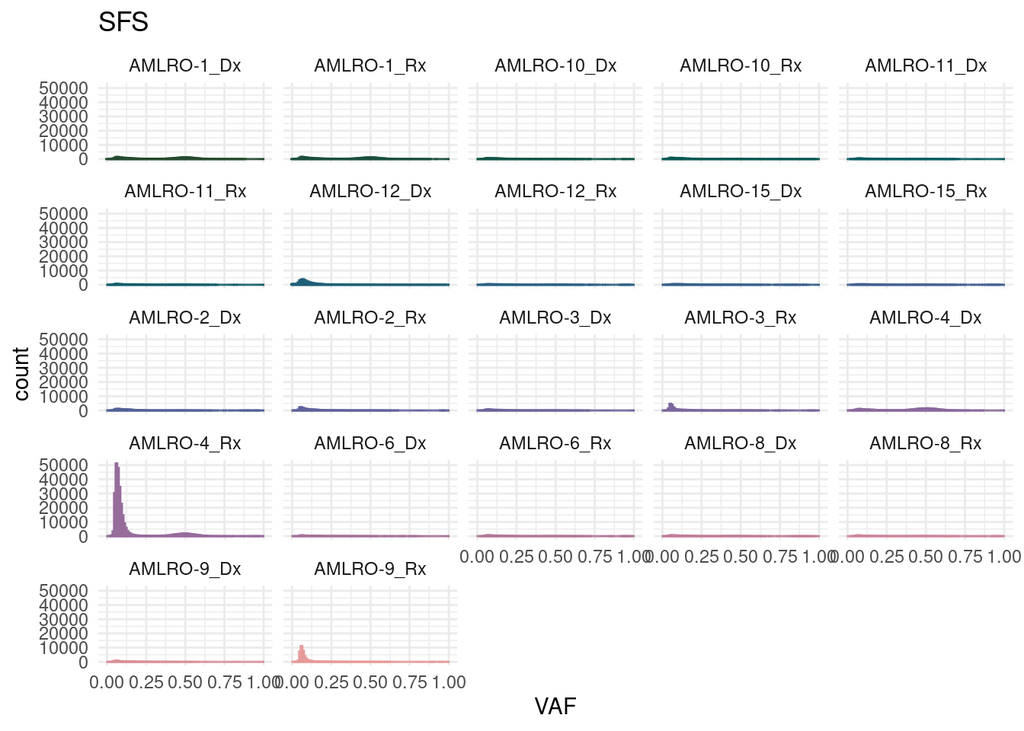

```r
plot_SFS(AMLRO, geom = "bar") +
  hide_legend() +
  facet_wrap(~sample_id)
```

```r
cd <- AMLRO |>
  run_cevomod()
```

Fitted model:

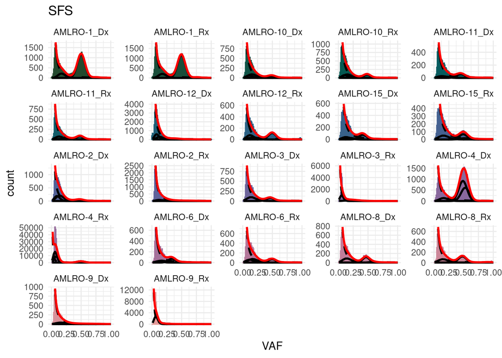

```r
plot_models(cd) +
  hide_legend()
```

# Main poster plot

Let’s use here AMLRO-3_Dx sample, and use different geoms to make in look better

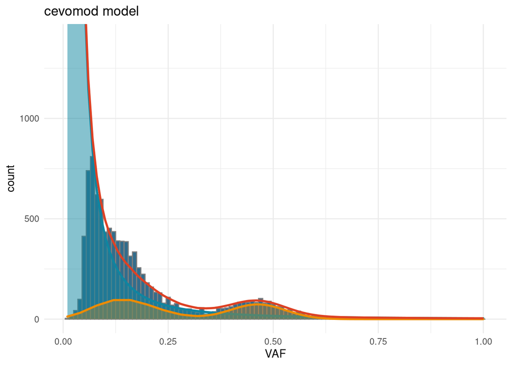

```r
cd3 <- cd |>
  filter(sample_id == "AMLRO-3_Dx")

neutral_models <- get_neutral_models(cd3) |>
  select(.data$sample_id, .data$from, .data$to)

resid <- cevomod:::get_residuals(cd3) |>
  left_join(neutral_models, by = "sample_id") |>
  group_by(.data$sample_id) |>
  mutate(ylim = Inf) |>
  ungroup() |>
  mutate(neutr = .data$VAF >= .data$from & .data$VAF <= .data$to)

colors <- c(
  data = "#00496FFF",
  `Neutral Tail` = "#0F85A0FF",
  Clones = "#ED8B00FF",
  `Final fit` = "#DD4124FF"
)

plot_SFS(cd3, geom = "bar", fill = "#00496FFF", alpha = 0.8, show.legend = FALSE) +
  geom_area(
    aes(.data$VAF, .data$neutral_pred),
    data = resid |> filter(.data$neutral_pred < .data$ylim),
    color = "#0F85A0FF", size = 1, fill = "#0F85A0FF", alpha = 0.5
  ) +
  geom_area(
    aes(.data$VAF, .data$binom_pred),
    data = resid,
    color = "#ED8B00FF", size = 1, fill = "#ED8B00FF", alpha = 0.3
  ) +
  geom_line(
    aes(.data$VAF, .data$model_pred),
    data = resid |> filter(.data$neutral_pred < .data$ylim),
    size = 1, color = "#DD4124FF"
  ) +
  scale_color_manual(values = colors) +
  scale_fill_manual(values = colors) +
  coord_cartesian(ylim = c(0, 1400)) +
  labs(title = "cevomod model")
```

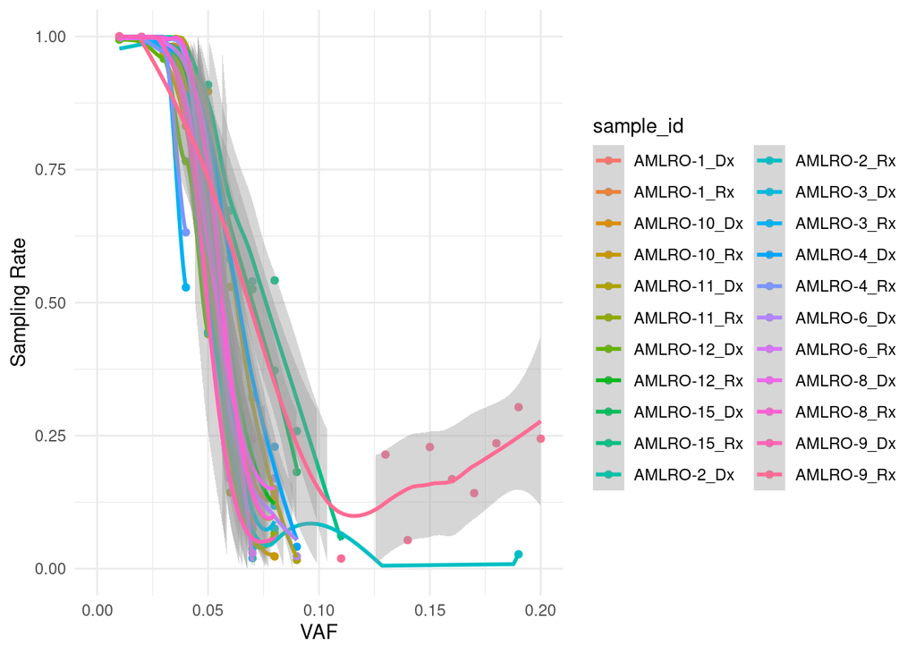

```r
plot_sampling_rate(cd) +
  ylim(0, 1) +
  xlim(0, 0.2) +
  geom_smooth()
```

## Bibliography

Caravagna, Giulio, Timon Heide, Marc J Williams, Luis Zapata, Daniel Nichol, Ketevan Chkhaidze, William Cross, et al. 2020. “Subclonal Reconstruction of Tumors by Using Machine Learning and Population Genetics.” *Nat. Genet.* 52 (9): 898–907.